# Unit 3 Tutorial

## Class activities

Please post your answers to Exercise 1 on Piazza. Each group only needs to submit once.

#### Exercise 1

Disk drives have been getting larger. Their capacity is now often given in terabytes (TB) where 1 TB = 1000 gigabytes, or about a trillion bytes. A search of prices for external disk drives on Amazon.com in early 2014 found the following data:

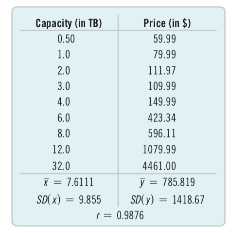

1. Find the slope estimate, $b_1$.
2. What does it mean in this context?
3. Find the intercept, $b_0$.
4. What does it mean, in this context? Is it meaningful?
5. Write down the equation that predicts Price from Capacity.
6. What would you predict for the price of a 20 TB drive?
7. A 20 TB drive on Amazon.com was listed at $2017.86. According to the model, does this seem like a good buy? How much would you save compared to what you expected to pay?
8. Does the model overestimate or underestimate the price?

## Optional

#### Exercise 2

For many people, breakfast cereal is an important source of fiber in their diets. Cereals also contain potassium, a mineral shown to be associated with maintaining a healthy blood pressure. An analysis of the amount of fiber (in grams) and the potassium content (in milligrams) in servings of 77 breakfast cereals produced the regression model

$$\widehat{\text{Potassium}} = 38 + 27~ \text{Fiber}.$$

1. If your cereal provides 9 grams of fiber per serving, how much potassium does the model estimate you will get?
2. What does it mean to say that a cereal has a negative residual?
3. Explain what the slope means.
4. Explain what the intercept means.

#### Exercise 3

A random sample of records of home sales from Feb. 15 to Apr. 30, 1993, from the files maintained by the Albuquerque Board of Realtors gives the Price and Size (in square feet) of 117 homes. The regression analysis gives the model

$$\widehat{\text{Price}} = 47.82 + 0.061 \text{Size}.$$

1. Explain what the slope of the line says about housing prices and house size.
2. What price would you predict for a 3000-square-foot house in this market?
3. A real estate agent shows a potential buyer a 1200-square-foot home, saying that the asking price is $6000 less than what one would expect to pay for a house of this size. What is the asking price, and what is the $6000 called?